# Modelo de efectos mixtos, machine learning y deep learning

## **Resumen de trabajos de interés**

[figure not shown]

[figure not shown]

## **Un pequeño repaso**

La inteligencia artificial es el nombre de todo un campo de conocimiento, similar a la biología o la química. El machine learning es una rama de la inteligencia artificial que viene ganando popularidad.

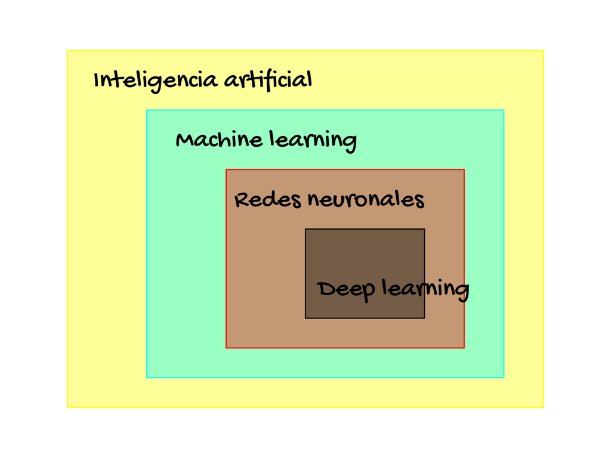

Las redes neuronales son uno de los tipos de machine learning. Uno popular, pero hay otros también muy buenos. El deep learning es un método moderno de construcción, capacitación y uso de redes neuronales. Básicamente, es una nueva arquitectura.

## **Un pequeño repaso**

Nunca hay una única forma de resolver un problema en el mundo del machine learning. Siempre hay varios algoritmos que se ajustan, y se debe elegir el mejor.

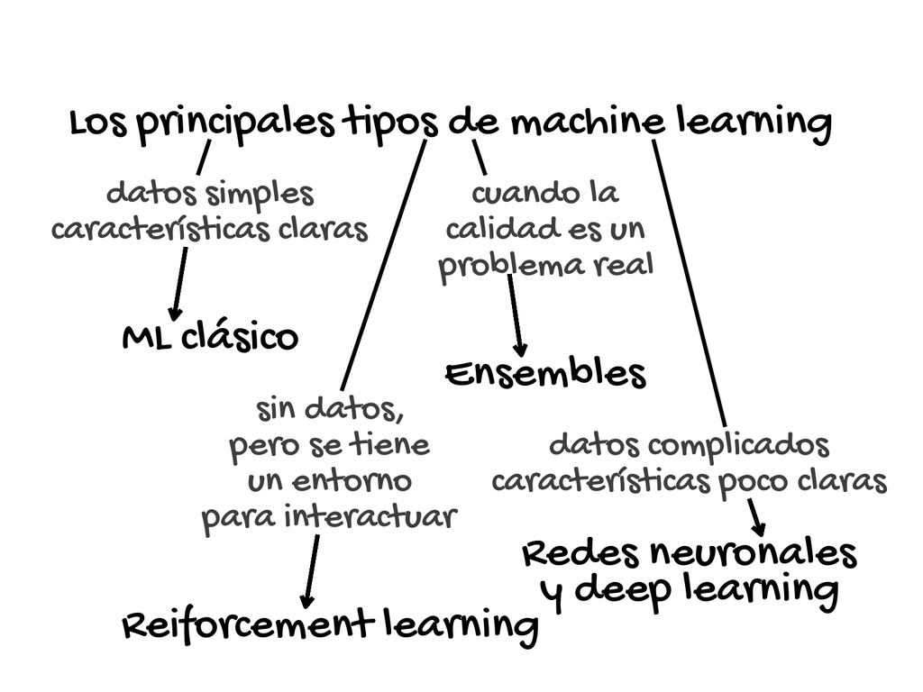

Las técnicas y métodos de machine learning pueden funcionar con una gran cantidad de datos complejos, de alta dimensión y enormes, y pueden usarse para desarrollar modelos de regresión y clasificación.

## **Un pequeño repaso**

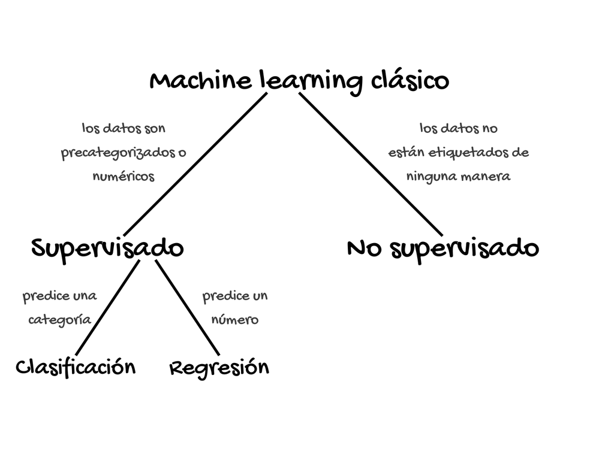

## **Un pequeño repaso**

En el aprendizaje supervisado, el modelo simplemente aprende a mapear las características de entrada dadas o la variable predictora $x$ y la variable de salida o respuesta $y$ en los conjuntos de datos de entrenamiento. La muestra de entrenamiento actúa como supervisor en el proceso de aprendizaje.

En el aprendizaje supervisado, cuando la variable de salida es un valor categórico o discreto, entonces es clasificación, pero cuando la variable de salida es un valor continuo, entonces es una regresión. [Aquí](https://www.youtube.com/watch?v=LliMpfMtjEo) un video sobre esto.

## **Un pequeño repaso**

La fórmula simple para explicar el problema de regresión (en el estudio a desarrollar se esta interesado en el problema de regresión) viene dada por la ecuación:

$$y = f(x) + b$$

El propósito de la regresión es estimar el valor de la variable respuesta $y$ utilizando la función $f(x)$ a partir de conjuntos de datos de entrada dados y su término de errores.

En la regresión, el modelo aprende de los datos en diversas técnicas para minimizar el sesgo y la varianza hasta que en algún momento la predicción del modelo haya logrado el mejor ajuste.

## **Un pequeño repaso**

Se pueden usar muchos algoritmos de regresión de machine learning para predecir la salida continua:

**Random forest (bosque al azar)**

Para entender los clasificadores de bosques al azar se necesita primero introducir el concepto de árboles de decisión.

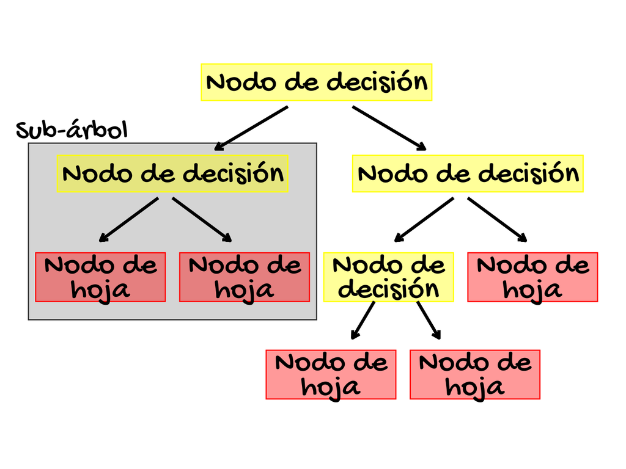

## **Un pequeño repaso**

Un árbol de decisión (como se pudo observar en la imagen anterior) es una estructura similar a un diagrama de flujo, en la que cada nodo interno representa una prueba sobre un atributo del conjunto de datos, cada marca representa el resultado de la prueba y cada hoja representa una etiqueta de clase.

## **Un pequeño repaso**

El modelo mixto es un modelo estadístico que comprende efectos fijos y efectos aleatorios.

Los modelos de efectos mixtos son adecuados para conjuntos de datos que tienen estructura de clúster. La estructura del clúster puede ser longitudinal (imagen a la izquierda) o jerárquica (imagen a la derecha).

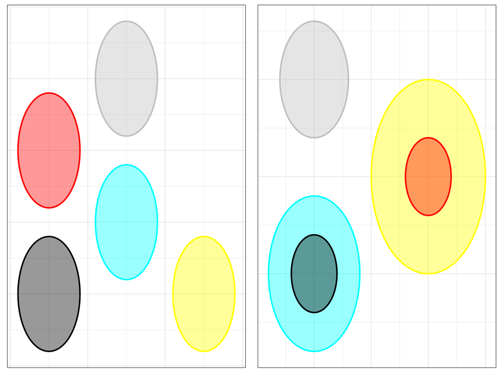

## **Un pequeño repaso**

Se ha propuesto un enfoque para manejar el clúster en los datos, el machine learning de efectos mixtos.

[figure not shown]

## **Un pequeño repaso**

### **Trabajo: compare machine learning methods and linear mixed models with random effects of longitudinal data prediction**

Problema: Los autores mencionan que los modelos comunmente usados (en este caso, con datos longitudinales) trabajan bajo supuestos hechos en la distribución de los datos y del modelo… los métodos tradicionales tienen una fuerte dependencia de los supuestos.

En comparación con los métodos tradicionales, los métodos de machine learning no requieren suposiciones sobre la distribución de los datos, y utilizan la validación cruzada para juzgar la calidad del modelo en su lugar.